# Text Mining (Tweets about Sprint)

## Name : Rohit Shenvi Diwadkar

## Text Mining

We are doing Text Mining on data of tweets about Sprint.

```r
install.packages("data.table", repos = "https://cran.r-project.org")
library(data.table)
```

we use package “dplyr” to easily aggregate our text documents.So If we want to find the most common word in all of the tweets about Sprint, we need to aggregate them into a single document and then count the word frequencies.

```r
data = fread("J:/tweets_about_sprint.csv",
             strip.white=T, sep=",", header=T, na.strings=c(""," ", "NA","nan", "NaN", "nannan"))
data
```

```
##                   user
##     1:       CA2016_sp
##     2: lety_rodriguezz
##     3: samanthajfacci1
##     4:      KimGibbs90
##     5:       khyleedt_
##    ---
## 49996:      SunSolaris
## 49997:    Leo_Mosquito
## 49998:  AustinBrooksie
## 49999:     JustinC0714
## 50000:     christafaux
##                                                                                                                                    tweet
##     1:    Ya casi es hora del FanHQ de sprint en ShowboxPresents Hoy 6pm Entrada gratis m sica en vivo y mucho m s https t co MLoPL7jBcs
##     2:                                                                   sprintcare everything is figured out now but sprint still sucks
```

[output cut: 21 more lines]

```r
data$tweet_id <- seq.int(nrow(data))

head(data, n=5)
```

```
##               user
## 1:       CA2016_sp
## 2: lety_rodriguezz
## 3: samanthajfacci1
## 4:      KimGibbs90
## 5:       khyleedt_
##                                                                                                                             tweet
## 1: Ya casi es hora del FanHQ de sprint en ShowboxPresents Hoy 6pm Entrada gratis m sica en vivo y mucho m s https t co MLoPL7jBcs
## 2:                                                                sprintcare everything is figured out now but sprint still sucks
## 3:                                                                                          sprint too bad we didn t post in time
## 4:                                                 I just checked in Sprint with mPLUSPlaces Download today https t co VjzSMxQcVX
## 5:                                                                          RT JPowell124 Monthly reminder tht sprint still sucks
##            date tweet_id
## 1: 6/16/16 0:00        1
## 2: 6/16/16 0:01        2
## 3: 6/16/16 0:03        3
## 4: 6/16/16 0:03        4
## 5: 6/16/16 0:04        5
```

```r
install.packages("tidytext", repos = "https://cran.r-project.org")
install.packages("dplyr", repos = "https://cran.r-project.org")
library(dplyr)
library(tidytext)
```

Within our tidy text framework, we need to both break the text into individual tokens (tokenization) and transform it to a tidy data structure. To do this, we use tidytext’s unnest_tokens() function.

The function unnest_tokens above splits each row such that there is one token (word) in each row of the new data frame.

```r
tidy_text <- data %>%
  unnest_tokens(word, tweet)
```

we can remove stop-words from our data.

```r
data(stop_words)
```

We can do this using anti_join function.

```r
tidy_text <- tidy_text %>%
  anti_join(stop_words)
```

We can also use dplyr’s count() to find the most common words in all the datasets as a whole

```r
tidy_text %>%
  count(word, sort = TRUE)
```

```
## # A tibble: 38,767 x 2
##    word           n
##    <chr>      <int>
##  1 sprint     45952
##  2 https      30369
##  3 rt         19618
##  4 verizon    10389
##  5 amp         8013
##  6 sprintcare  7794
##  7 geico       5461
##  8 wellsfargo  4947
##  9 mobile      3912
## 10 download    3717
## # ... with 38,757 more rows
```

our word counts are stored in a tidy data frame. This allows us to pipe this directly to the ggplot2 package, for example to create a visualization of the most common words.

```r
library(ggplot2)
```

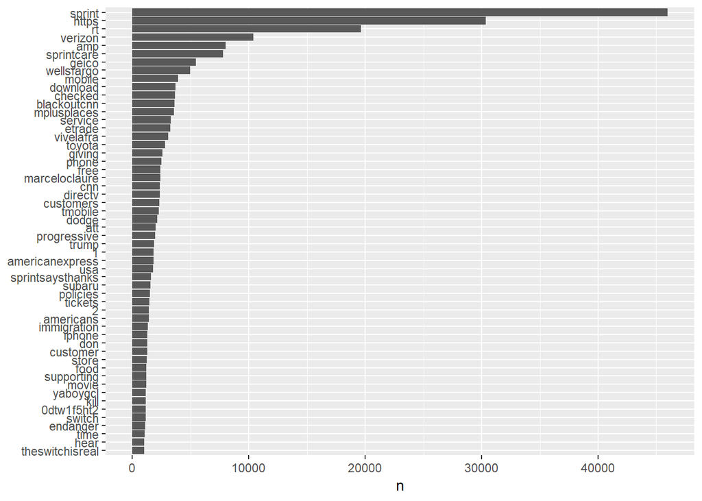

```r
tidy_text %>%
  count(word, sort = TRUE) %>%
  filter(n > 1000) %>%
  mutate(word = reorder(word, n)) %>%
  ggplot(aes(word, n)) +
  geom_bar(stat = "identity") +
  xlab(NULL) +
  coord_flip()
```

Let’s start by looking at the tweets and examine term frequency and tf-idf. We can start just by using dplyr verbs such as group_by() and join().

We will have one document per user (which contains all of the tweets posted by that user). Therefore, the number of documents would be equal to the number of unique users in the original data.

```r
tweet_words <- data %>%
  unnest_tokens(word, tweet) %>%
  count(user, word, sort = TRUE) %>%
  ungroup()
```

```r
total_words <- tweet_words %>%
  group_by(user) %>%
  summarize(total = sum(n))
```

```r
head(total_words)
```

```
## # A tibble: 6 x 2
##   user          total
##   <chr>         <int>
## 1 ______ChrisJ     24
## 2 ______MARISOL    23
## 3 ____Baroo        16
## 4 ____BRANEISHA    70
## 5 ____Cook____      7
## 6 ____IDFWU         9
```

```r
tweet_words <- left_join(tweet_words, total_words)
head(tweet_words)
```

```
## # A tibble: 6 x 4
##   user       word            n total
##   <chr>      <chr>       <int> <int>
## 1 KeepMyCoat cnnblackout   275  4046
## 2 KeepMyCoat https         275  4046
## 3 KeepMyCoat sprint        275  4046
## 4 KeepMyCoat etrade        274  4046
## 5 KeepMyCoat geico         274  4046
## 6 KeepMyCoat wellsfargo    274  4046
```

There is one row in this tweet_words data frame for each word-user combination; n is the number of times that word is used by that user and total is the total words used by that user. If we divide n by total, we will get tf:

```r
tweet_words <- tweet_words %>%
  bind_tf_idf(word, user, n)
```

```r
head(tweet_words)
```

```
## # A tibble: 6 x 7
##   user       word            n total     tf    idf  tf_idf
##   <chr>      <chr>       <int> <int>  <dbl>  <dbl>   <dbl>
## 1 KeepMyCoat cnnblackout   275  4046 0.0680 5.89   0.401
## 2 KeepMyCoat https         275  4046 0.0680 0.557  0.0378
## 3 KeepMyCoat sprint        275  4046 0.0680 0.0662 0.00450
## 4 KeepMyCoat etrade        274  4046 0.0677 2.60   0.176
## 5 KeepMyCoat geico         274  4046 0.0677 2.15   0.145
## 6 KeepMyCoat wellsfargo    274  4046 0.0677 2.22   0.151
```

The idea of tf-idf is to find the important words for the content of each document (all of the tweets per user) by decreasing the weight for commonly used words and increasing the weight for words that are not used very much in a collection or corpus of documents.

Sentiment Analysis:

Lexicons we are going to use are based on unigrams, i.e., single words. These lexicons contain many English words and the words are assigned scores for positive/negative sentiment, and also possibly emotions like joy, anger, sadness, and so forth.

The nrc lexicon categorizes words in a binary fashion (“yes”/“no”) into categories of positive, negative, anger, anticipation, disgust, fear, joy, sadness, surprise, and trust.

The bing lexicon categorizes words in a binary fashion into positive and negative categories.

All of this information is tabulated in the sentiments dataset, and tidytext provides a function get_sentiments() to get specific sentiment lexicons without the columns that are not used in that lexicon.

look at the words with a joy score from the NRC lexicon.

```r
nrcjoy <- get_sentiments("nrc") %>%
  filter(sentiment == "joy")
```

```r
tidy_text %>%
  inner_join(nrcjoy) %>%
  count(word, sort = TRUE)
```

```
## # A tibble: 275 x 2
##    word      n
##    <chr> <int>
##  1 food   1212
##  2 pay     842
##  3 save    490
##  4 happy   452
##  5 money   388
##  6 love    373
##  7 deal    248
##  8 fun     218
##  9 hope    157
## 10 white   139
## # ... with 265 more rows
```

we could measure the sentiment of the tweets. We find a sentiment score for each word using the Bing lexicon and inner_join().

```r
sentiment <- tidy_text %>%
  inner_join(get_sentiments("bing")) %>%
  count(word, sentiment, sort = TRUE)
head(sentiment)
```

```
## # A tibble: 6 x 3
##   word        sentiment     n
##   <chr>       <chr>     <int>
## 1 free        positive   2422
## 2 progressive positive   1953
## 3 trump       positive   1877
## 4 supporting  positive   1192
## 5 kill        negative   1165
## 6 endanger    negative   1105
```

```r
sentiment <- tidy_text %>%
  filter(user == "KeepMyCoat") %>%
  inner_join(get_sentiments("bing")) %>%
  count(word, sentiment, sort = TRUE)
```

Let’s look at the most common words in our Twitter data.

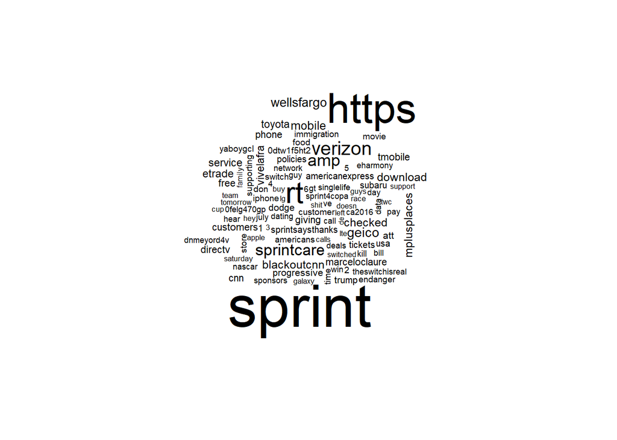

```r
library(wordcloud)
tidy_text %>%
  anti_join(stop_words) %>%
  count(word) %>%
  with(wordcloud(word, n, max.words = 100))
```

Let’s do the sentiment analysis to tag positive and negative words using an inner join, then find the most common positive and negative words.

```r
library(reshape2)
```

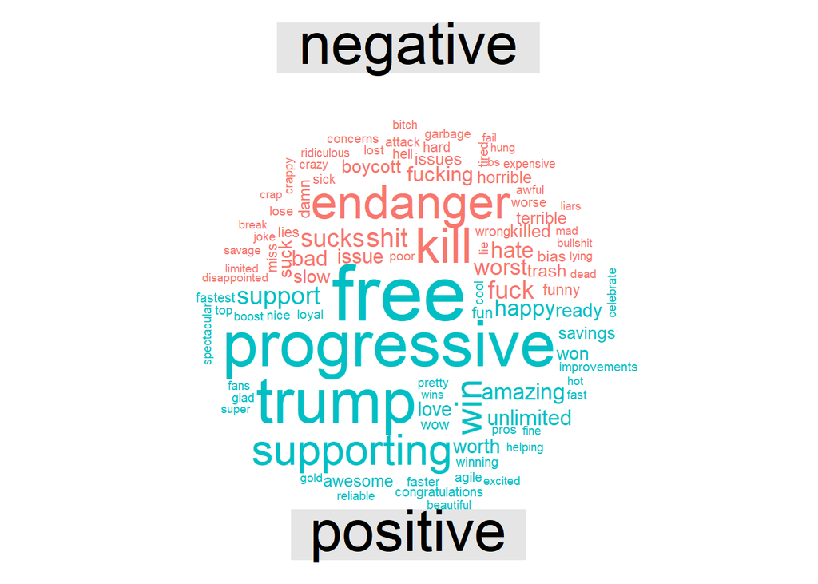

```r
tidy_text %>%
  inner_join(get_sentiments("bing")) %>%
  count(word, sentiment, sort = TRUE) %>%
  acast(word ~ sentiment, value.var = "n", fill = 0) %>%
  comparison.cloud(colors = c("#F8766D", "#00BFC4"),
                   max.words = 100)
```

Topic Modelling:

Topic modeling is a method for unsupervised classification of such documents, similar to “clustering” on numerical data, which finds natural groups of items even when we’re not sure what we’re looking for.

Latent Dirichlet allocation is a particularly popular method for fitting a topic model. It treats each document as a mixture of topics, and each topic as a mixture of words. This allows documents to “overlap” each other in terms of content, rather than being separated into discrete groups, in a way that mirrors typical use of natural language.

```r
library(tm)
```

```r
library(wordcloud)
library(topicmodels)
library(slam)
```

We use the LDA() function from the topicmodels package, setting k = 2, to create a two-topic LDA model.

```r
data <- data[1:1000,]
```

```r
corpus <- Corpus(VectorSource(data$tweet), readerControl=list(language="en"))
```

```r
tweet_dtm <- DocumentTermMatrix(corpus, control = list(stopwords = TRUE, minWordLength = 3, removeNumbers = TRUE, removePunctuation = TRUE))
```

```r
tweet_dtm
```

```
## <<DocumentTermMatrix (documents: 1000, terms: 2399)>>
## Non-/sparse entries: 9442/2389558
## Sparsity           : 100%
## Maximal term length: 57
## Weighting          : term frequency (tf)
```

```r
lda <- LDA(tweet_dtm, k = 2, control = list(seed = 1234))
```

```r
lda
```

```
## A LDA_VEM topic model with 2 topics.
```

The tidytext package provides this method for extracting the per-topic-per-word probabilities from the model.

```r
library(tidytext)
```

```r
lda_td <- tidy(lda)
```

```r
top_terms <- lda_td %>%
  group_by(topic) %>%
  top_n(10, beta) %>%
  ungroup() %>%
  arrange(topic, -beta)
```

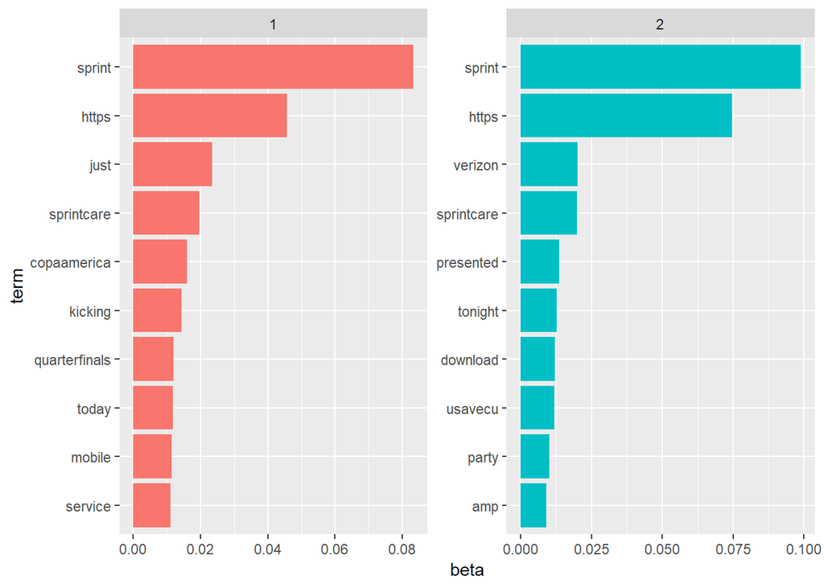

```r
top_terms %>%
  mutate(term = reorder(term, beta)) %>%
  ggplot(aes(term, beta, fill = factor(topic))) +
  geom_bar(stat = "identity", show.legend = FALSE) +
  facet_wrap(~ topic, scales = "free") +
  coord_flip()
```

This visualization lets us understand the two topics that were extracted from the tweets.

Improvisation:

```r
wordstoremove <- c("https", "just")
data_sub <- as.data.frame(sapply(data, function(x) gsub(paste(wordstoremove, collapse = '|'), '', x)))
corpus <- Corpus(VectorSource(data_sub$tweet), readerControl=list(language="en"))
tweet_dtm <- DocumentTermMatrix(corpus, control = list(stopwords = TRUE, minWordLength = 1, removeNumbers = TRUE, removePunctuation = TRUE))
dim(tweet_dtm)
```

```
## [1] 1000 2398
```

```r
lda <- LDA(tweet_dtm, k = 2, control = list(seed = 1234))
lda
```

```
## A LDA_VEM topic model with 2 topics.
```

```r
library(tidytext)
lda_td <- tidy(lda)
lda_td
```

```
## # A tibble: 4,796 x 3
##    topic term         beta
##    <int> <chr>       <dbl>
##  1     1 casi    0.000239
##  2     2 casi    0.000204
##  3     1 del     0.000508
##  4     2 del     0.000378
##  5     1 entrada 0.000373
##  6     2 entrada 0.0000700
##  7     1 fanhq   0.0159
##  8     2 fanhq   0.000689
##  9     1 gratis  0.000247
## 10     2 gratis  0.000196
## # ... with 4,786 more rows
```

```r
top_terms <- lda_td %>%
  group_by(topic) %>%
  top_n(10, beta) %>%
  ungroup() %>%
  arrange(topic, -beta)
```

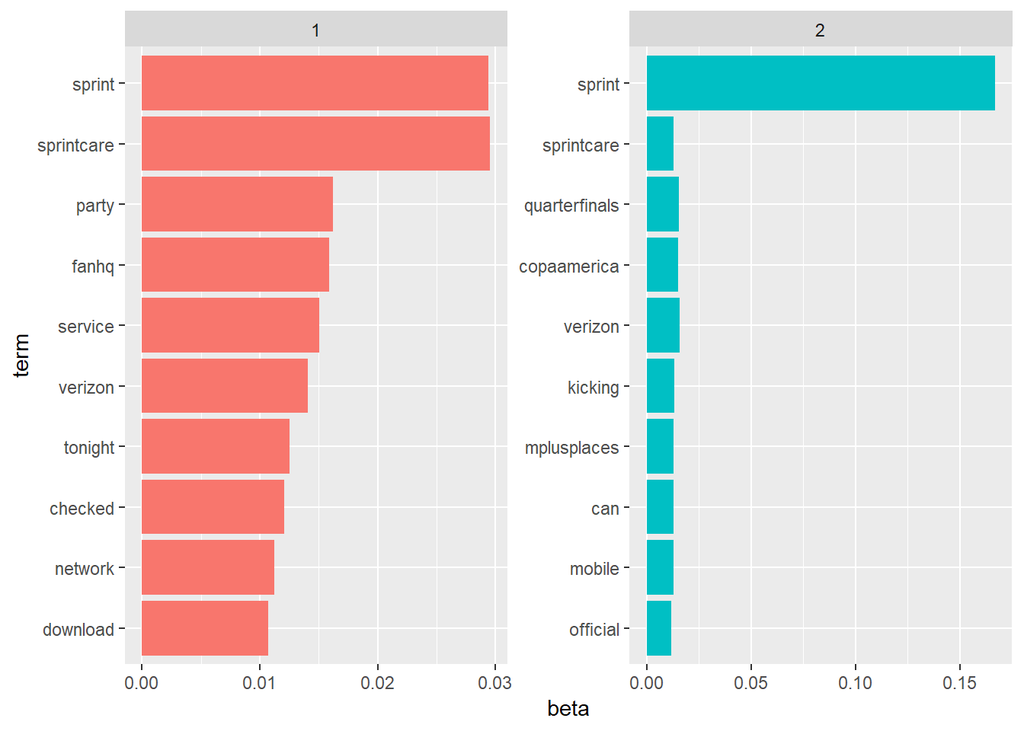

```r
top_terms %>%
  mutate(term = reorder(term, beta)) %>%
  ggplot(aes(term, beta, fill = factor(topic))) +
  geom_bar(stat = "identity", show.legend = FALSE) +
  facet_wrap(~ topic, scales = "free") +
  coord_flip()
```